# InVivoStat Equivalence TOST Test Analysis

## Response and equivalence bounds

The Resp 1 response is currently being analysed by the Equivalence (TOST) test Analysis module.The response has been loge transformed prior to analysis.

The lower equivalence bound is defined as a 10.00 % (decrease) change. The upper equivalence bound is defined as a 10.00 % (increase) change. As both boundaries are defined a two one-sided (TOST) equivalence test has been performed.

## Scatterplot of the observed data (on the loge scale)

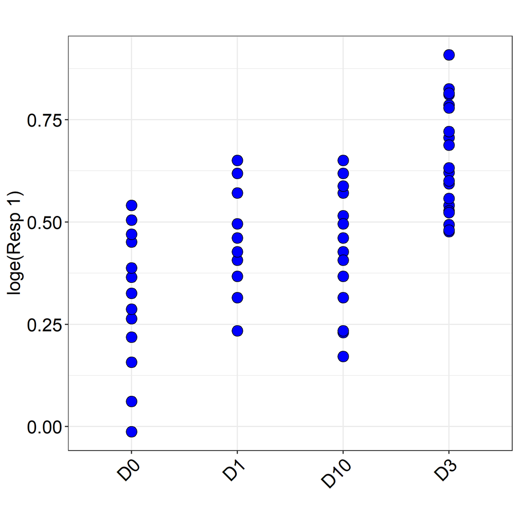

Tip: Use this plot to identify possible outliers.

## Model coefficients

|  | Estimate | Std. Error | t-value | p-value |
| --- | --- | --- | --- | --- |
| (Intercept) | 0.4624 | 0.0167 | 27.67 | < 0.0001 |
| Treat11 | -0.1402 | 0.0297 | -4.72 | < 0.0001 |
| Treat12 | -0.0225 | 0.0287 | -0.78 | 0.4353 |
| Treat13 | -0.0292 | 0.0287 | -1.02 | 0.3118 |

## Table of the back-transformed geometric means with 95% confidence intervals

As the response was log transformed prior to analysis the means are presented back transformed onto the original scale. These are known as the back-transformed geometric means.

| Mean ID | Treat1 | Geometric mean | Lower 95% CI | Upper 95% CI |
| --- | --- | --- | --- | --- |
| 1 | D0 | 1.380 | 1.288 | 1.479 |
| 2 | D1 | 1.553 | 1.454 | 1.658 |
| 3 | D10 | 1.542 | 1.444 | 1.647 |
| 4 | D3 | 1.924 | 1.802 | 2.055 |

## Plot of the back-transformed geometric means with 95% confidence intervals

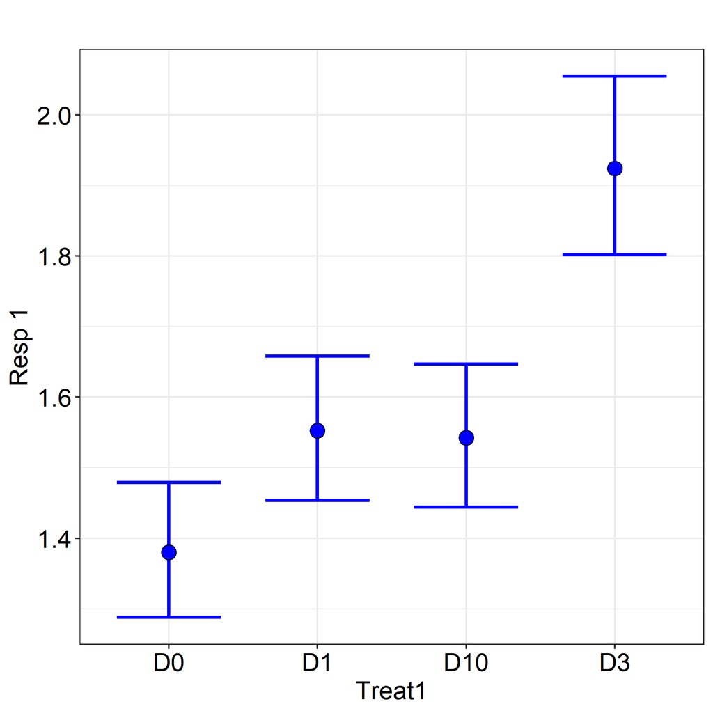

## All pairwise equivalence assessments

| Comparison | % change | Lower one-sided 95% CI | Upper one-sided 95% CI | Lower % change equivalence bound | Upper % change equivalence bound | Equivalence assessment |
| --- | --- | --- | --- | --- | --- | --- |
| D0 / D1 | -11.107 | -17.924 | -3.725 | -10 | 10 | Inconclusive |
| D0 / D10 | -10.509 | -17.371 | -3.077 | -10 | 10 | Inconclusive |
| D0 / D3 | -28.264 | -33.765 | -22.306 | -10 | 10 | Not equivalent |
| D1 / D10 | 0.673 | -6.849 | 8.802 | -10 | 10 | Equivalent |
| D1 / D3 | -19.300 | -25.330 | -12.784 | -10 | 10 | Not equivalent |
| D10 / D3 | -19.840 | -25.829 | -13.367 | -10 | 10 | Not equivalent |

## Plot of the comparisons between the predicted means with 95% one-sided confidence intervals along with equivalence bounds

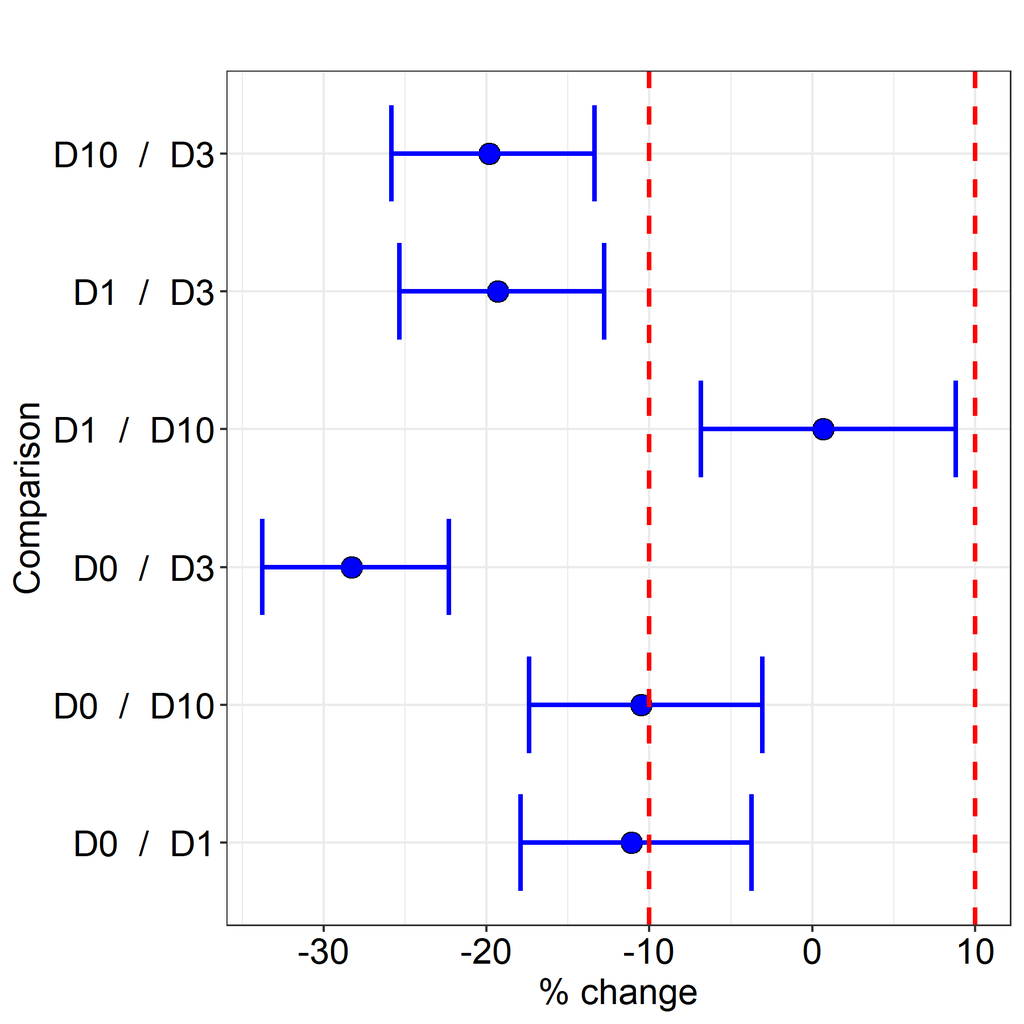

## Conclusion

Conclusion: The following means are deemed equivalent at the 5% level: D1 and D10.

## Diagnostic plot

### Residuals vs. predicted plot

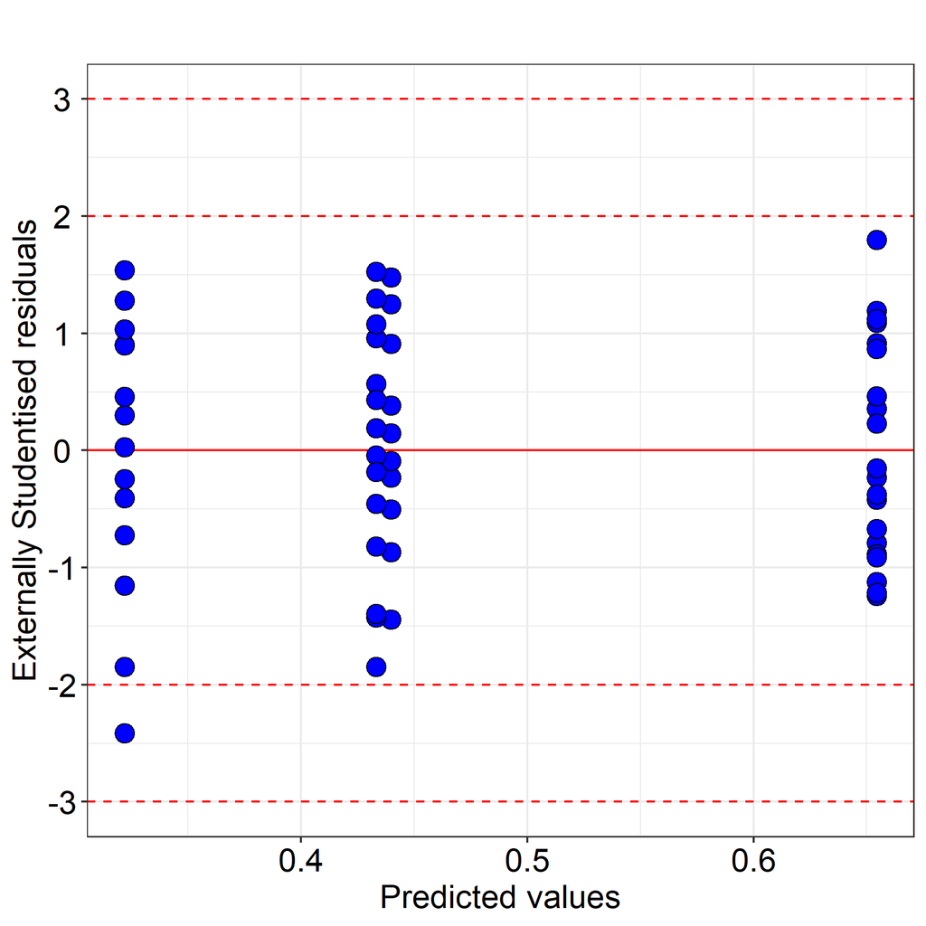

Tip: On this plot look to see if the spread of the points increases as the predicted values increase. If so the response may need transforming.

Tip: Any observation with a residual less than -3 or greater than 3 (SD) should be investigated as a possible outlier.

## Analysis description

The data were analysed using a Two One-Sided (TOST) equivalence test, see Limentani et al. 2005, with Treat1 as the treatment factor. The response was loge transformed prior to analysis to stabilise the variance.

For more information on the theoretical approaches that are implemented within this module, see Bate and Clark (2014).

## References

When referring to InVivoStat, please cite 'InVivoStat, version 5.2.0'.

Bate, S.T. and Clark, R.A. (2014). The Design and Statistical Analysis of Animal Experiments. Cambridge University Press.

Limentani, G.B., Ringo, M.C., Ye, F., Bergquist, M.L. and MCSorley E.O. (2005). Beyond the t-test: Statistical equivalence testing. Analytical Chemistry, 77(11), 221-226.